# HomeAway data 01

Radoslaw Panczak

10 September, 2019

# 1 Summary

This is an overview of **raw** `HomeAway` dataset.

Separate preparation is done for `ha` (properties) and `ham` (monthly) datasets.

# 2 Properties

## 2.1 General

- All variable names were converted to lower caps
- Dots/gaps in the names were replaced by single underscores.
- Completely empty variables (`Zipcode` and `Metropolitan_Statistical_Area`) were dropped.
- Variable `Country` was droped.
- Data was spatially linked to ABS geography with SA1 and above level variables added.

Dataset consists of 46 variables:

```
##  [1] "property_id"                "property_manager_id"
##  [3] "listing_title"              "property_type"
##  [5] "last_scraped_date"          "state"
##  [7] "city"                       "neighborhood"
##  [9] "average_daily_rate_usd"     "annual_revenue_ltm_usd"
## [11] "occupancy_rate_ltm"         "number_of_bookings_ltm"
## [13] "number_of_reviews"          "bedrooms"
## [15] "bathrooms"                  "max_guests"
## [17] "calendar_last_updated"      "response_rate"
## [19] "response_time_min"          "premier_partner"
## [21] "cancellation_policy"        "security_deposit_usd"
## [23] "cleaning_fee_usd"           "published_nightly_rate_usd"
## [25] "minimum_stay"               "count_reservation_days_ltm"
## [27] "count_available_days_ltm"   "count_blocked_days_ltm"
## [29] "number_of_photos"           "instantbook_enabled"
## [31] "listing_url"                "listing_main_image_url"
## [33] "latitude"                   "longitude"
## [35] "overall_rating"             "SA1_MAIN16"
## [37] "SA1_7DIG16"                 "SA2_MAIN16"
## [39] "SA2_5DIG16"                 "SA2_NAME16"
## [41] "SA3_CODE16"                 "SA3_NAME16"
## [43] "SA4_CODE16"                 "SA4_NAME16"
## [45] "STE_CODE16"                 "STE_NAME16"
```

## 2.2 Data structure

Skim summary statistics  
n obs: 83297  
n variables: 46

Variable type: character

| variable | missing | complete | n | min | max | empty | n_unique |
| --- | --- | --- | --- | --- | --- | --- | --- |
| cancellation_policy | 0 | 83297 | 83297 | 2 | 123 | 0 | 12 |
| city | 7459 | 75838 | 83297 | 4 | 30 | 0 | 256 |
| listing_main_image_url | 3 | 83294 | 83297 | 47 | 83 | 0 | 83294 |
| listing_title | 0 | 83297 | 83297 | 4 | 279 | 0 | 78044 |
| listing_url | 0 | 83297 | 83297 | 47 | 51 | 0 | 83297 |
| neighborhood | 16382 | 66915 | 83297 | 3 | 39 | 0 | 3532 |
| property_id | 0 | 83297 | 83297 | 5 | 9 | 0 | 83297 |
| property_manager_id | 40314 | 42983 | 83297 | 1 | 58 | 0 | 79 |
| property_type | 38 | 83259 | 83297 | 4 | 23 | 0 | 29 |
| SA2_NAME16 | 0 | 83297 | 83297 | 3 | 43 | 0 | 1765 |
| SA3_NAME16 | 0 | 83297 | 83297 | 4 | 36 | 0 | 334 |
| SA4_NAME16 | 0 | 83297 | 83297 | 4 | 38 | 0 | 89 |
| state | 1431 | 81866 | 83297 | 8 | 28 | 0 | 8 |
| STE_NAME16 | 0 | 83297 | 83297 | 8 | 28 | 0 | 9 |

Variable type: Date

| variable | missing | complete | n | min | max | median | n_unique |
| --- | --- | --- | --- | --- | --- | --- | --- |
| calendar_last_updated | 588 | 82709 | 83297 | 2012-07-12 | 2019-01-24 | 2018-11-18 | 1155 |
| last_scraped_date | 0 | 83297 | 83297 | 2017-06-20 | 2019-01-24 | 2019-01-14 | 535 |

Variable type: logical

| variable | missing | complete | n | mean | count |
| --- | --- | --- | --- | --- | --- |
| instantbook_enabled | 0 | 83297 | 83297 | 0.19 | FAL: 67840, TRU: 15457, NA: 0 |
| premier_partner | 6393 | 76904 | 83297 | 0.000039 | FAL: 76901, NA: 6393, TRU: 3 |

Variable type: numeric

| variable | missing | complete | n | mean | sd | p0 | p25 | p50 | p75 | p100 | hist |
| --- | --- | --- | --- | --- | --- | --- | --- | --- | --- | --- | --- |
| annual_revenue_ltm_usd | 2485 | 80812 | 83297 | 9950.28 | 952828.56 | 0 | 0 | 2170 | 7394 | 270800608 | ▇▁▁▁▁▁▁▁ |
| average_daily_rate_usd | 29799 | 53498 | 83297 | 244.39 | 1565.44 | 1 | 122.11 | 175.88 | 273.36 | 358559 | ▇▁▁▁▁▁▁▁ |
| bathrooms | 431 | 82866 | 83297 | 1.76 | 1.08 | 0.5 | 1 | 2 | 2 | 82 | ▇▁▁▁▁▁▁▁ |
| bedrooms | 0 | 83297 | 83297 | 2.81 | 1.75 | 0 | 2 | 3 | 4 | 95 | ▇▁▁▁▁▁▁▁ |
| cleaning_fee_usd | 62894 | 20403 | 83297 | 105.29 | 84.64 | 1 | 51 | 79 | 136 | 3583 | ▇▁▁▁▁▁▁▁ |
| count_available_days_ltm | 29735 | 53562 | 83297 | 58.68 | 45.74 | 0 | 25 | 49 | 81 | 311 | ▇▆▃▂▁▁▁▁ |
| count_blocked_days_ltm | 29735 | 53562 | 83297 | 13.17 | 18.48 | 0 | 0 | 5 | 20 | 174 | ▇▂▁▁▁▁▁▁ |
| count_reservation_days_ltm | 29735 | 53562 | 83297 | 43.21 | 47.99 | 1 | 12 | 30 | 56 | 365 | ▇▃▁▁▁▁▁▁ |
| latitude | 0 | 83297 | 83297 | -33.42 | 5.18 | -43.46 | -37.57 | -33.89 | -31.65 | -10.45 | ▁▇▇▃▁▁▁▁ |
| longitude | 0 | 83297 | 83297 | 146.19 | 9.32 | 105.69 | 144.8 | 149.6 | 151.65 | 167.94 | ▁▁▁▁▂▇▃▁ |
| max_guests | 0 | 83297 | 83297 | 6.55 | 4.56 | 0 | 4 | 6 | 8 | 200 | ▇▁▁▁▁▁▁▁ |
| minimum_stay | 17770 | 65527 | 83297 | 1.62 | 4.26 | 0 | 0 | 1 | 2 | 180 | ▇▁▁▁▁▁▁▁ |
| number_of_bookings_ltm | 2485 | 80812 | 83297 | 5.05 | 7.38 | 0 | 0 | 2 | 8 | 77 | ▇▂▁▁▁▁▁▁ |
| number_of_photos | 0 | 83297 | 83297 | 14.57 | 8.85 | 0 | 8 | 14 | 20 | 51 | ▆▆▇▆▁▁▁▁ |
| number_of_reviews | 0 | 83297 | 83297 | 4.25 | 11.1 | 0 | 0 | 0 | 3 | 220 | ▇▁▁▁▁▁▁▁ |
| occupancy_rate_ltm | 29735 | 53562 | 83297 | 0.41 | 0.26 | 0.032 | 0.2 | 0.36 | 0.59 | 1 | ▆▇▆▅▅▃▂▃ |
| overall_rating | 50520 | 32777 | 83297 | 4.7 | 0.62 | 1 | 5 | 5 | 5 | 5 | ▁▁▁▁▁▂▁▇ |
| published_nightly_rate_usd | 3598 | 79699 | 83297 | 256.05 | 2554.86 | 1 | 125 | 180 | 280 | 716948 | ▇▁▁▁▁▁▁▁ |
| response_rate | 56596 | 26701 | 83297 | 90.95 | 16.17 | 0 | 90 | 100 | 100 | 100 | ▁▁▁▁▁▁▁▇ |
| response_time_min | 45865 | 37432 | 83297 | 3243.7 | 5811.77 | 60 | 300 | 1440 | 2880 | 20880 | ▇▃▁▁▁▁▁▁ |
| SA1_7DIG16 | 0 | 83297 | 83297 | 2348390.86 | 1415167.1 | 1100701 | 1127204 | 2108702 | 3127015 | 9100407 | ▇▅▃▂▁▁▁▁ |
| SA1_MAIN16 | 0 | 83297 | 83297 | 23178525888.25 | 13999720279.65 | 10102100701 | 11303126409 | 20503108702 | 30908125901 | 90104100407 | ▇▅▃▂▁▁▁▁ |
| SA2_5DIG16 | 0 | 83297 | 83297 | 23483.75 | 14151.69 | 11007 | 11272 | 21087 | 31270 | 91004 | ▇▅▃▂▁▁▁▁ |
| SA2_MAIN16 | 0 | 83297 | 83297 | 231785258.72 | 139997202.82 | 101021007 | 113031264 | 205031087 | 309081259 | 901041004 | ▇▅▃▂▁▁▁▁ |
| SA3_CODE16 | 0 | 83297 | 83297 | 23178.41 | 13999.72 | 10102 | 11303 | 20503 | 30908 | 90104 | ▇▅▃▂▁▁▁▁ |
| SA4_CODE16 | 0 | 83297 | 83297 | 231.76 | 140 | 101 | 113 | 205 | 309 | 901 | ▇▅▃▂▁▁▁▁ |
| security_deposit_usd | 81913 | 1384 | 83297 | 554.54 | 486.11 | 11 | 218.75 | 364 | 717 | 5000 | ▇▃▁▁▁▁▁▁ |
| STE_CODE16 | 0 | 83297 | 83297 | 2.23 | 1.42 | 1 | 1 | 2 | 3 | 9 | ▇▂▁▁▁▁▁▁ |

## 2.3 Missing data

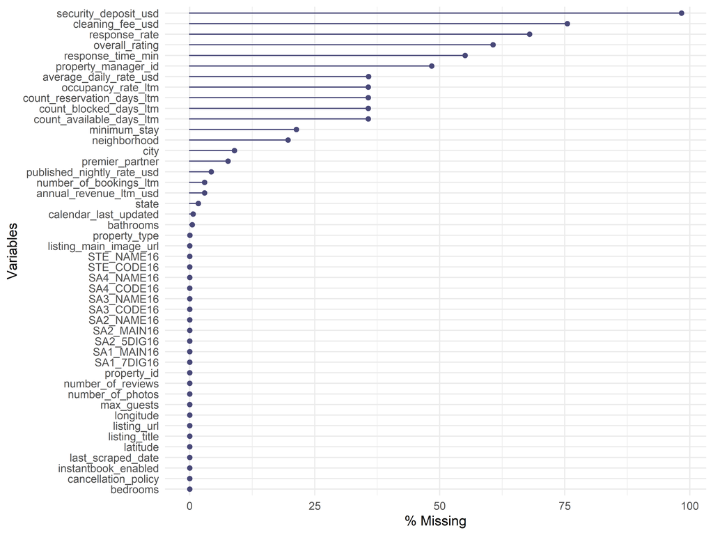

# 3 Property type

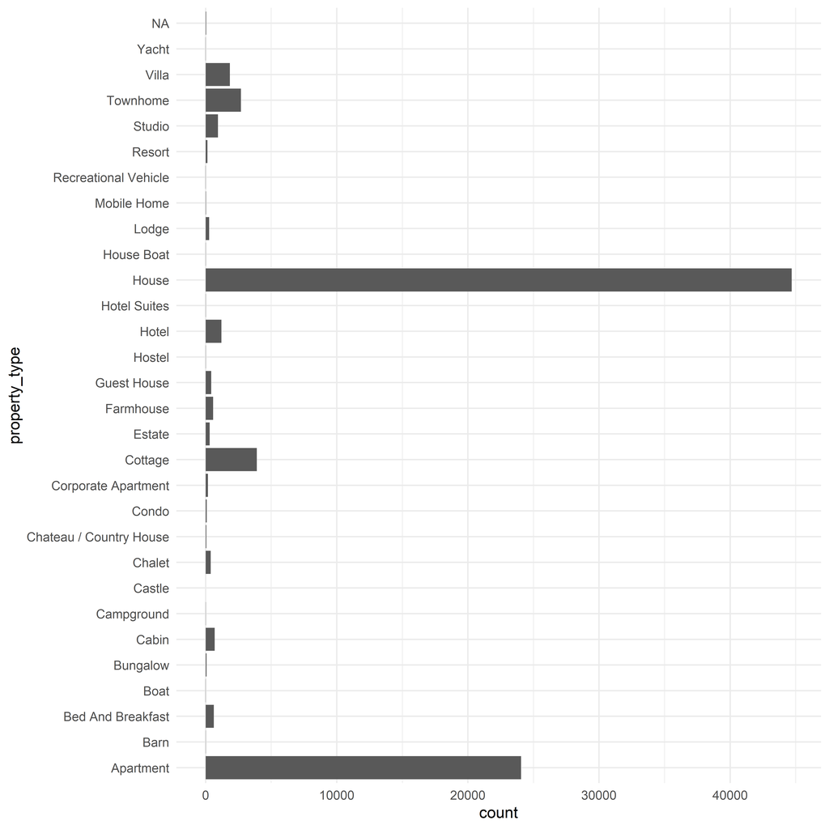

## 3.1 Occupancy Rate

```
## Descriptive Statistics
## hap$occupancy_rate_ltm
## N: 83297
##
##                occupancy_rate_ltm
## ------------ --------------------
##         Mean                 0.41
##       Median                 0.36
##          Min                 0.03
##          Max                 1.00
```

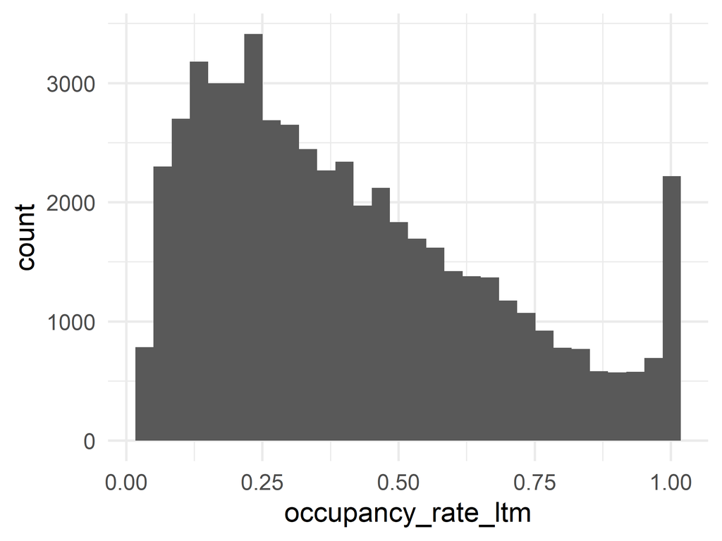

## 3.2 No of bedrooms

```
## Descriptive Statistics
## hap$bedrooms
## N: 83297
##
##                bedrooms
## ------------ ----------
##         Mean       2.81
##       Median       3.00
##          Min       0.00
##          Max      95.00
```

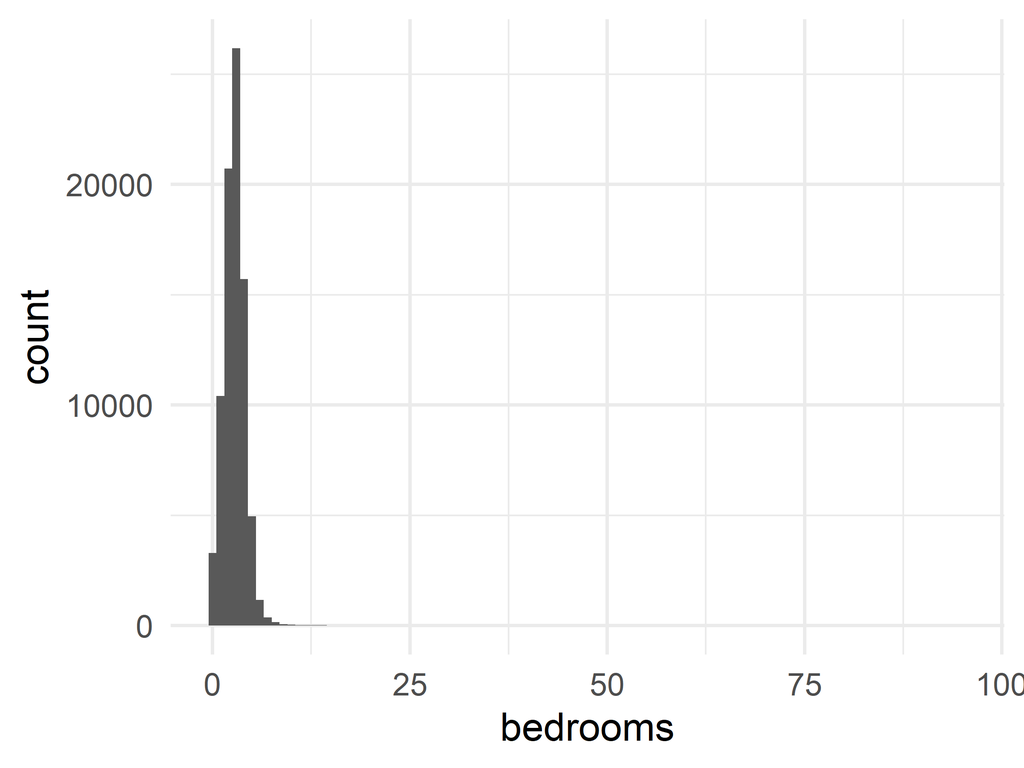

## 3.3 Max Guests

```
## Descriptive Statistics
## hap$max_guests
## N: 83297
##
##                max_guests
## ------------ ------------
##         Mean         6.55
##       Median         6.00
##          Min         0.00
##          Max       200.00
```

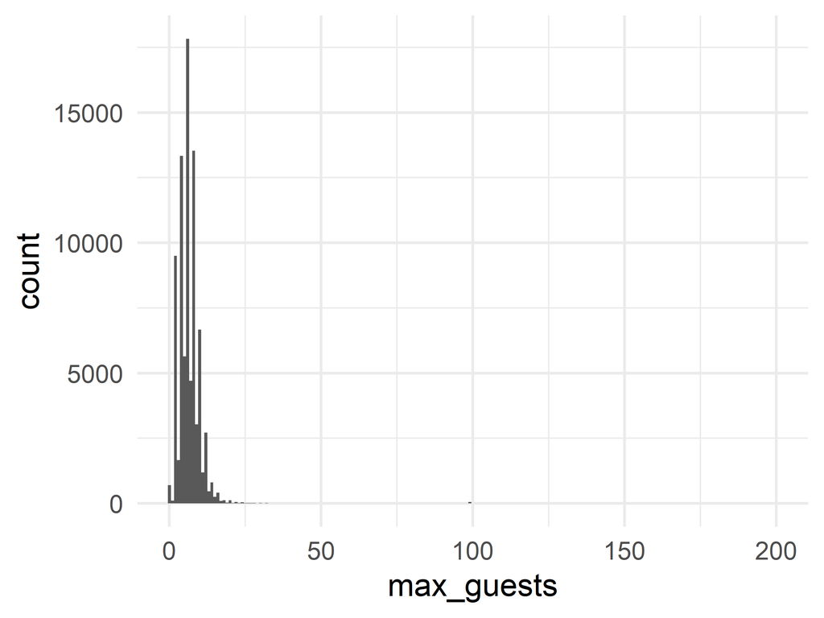

# 4 Monthly

- Dotsin the names were replaced by (single) underscores.
- Completely empty variables (`Zipcode` and `Metropolitan_Statistical_Area`) were dropped.
- Variable `Country` was droped.
- Variables `State`, `City` and `Neighborhood` were droped (no clue how assigned; will be added from ABS data linked spatially by coordinates)

Dataset consists of 1082116 records in 16 variables:

```
##  [1] "property_id"            "property_manager_id"
##  [3] "property_type"          "bedrooms"
##  [5] "reporting_month"        "occupancy_rate"
##  [7] "revenue_usd"            "adr_usd"
##  [9] "number_of_reservations" "reservation_days"
## [11] "available_days"         "blocked_days"
## [13] "latitude"               "longitude"
## [15] "active"                 "scraped_during_month"
```

## 4.1 Data structure

Skim summary statistics  
n obs: 1082116  
n variables: 16

Variable type: character

| variable | missing | complete | n | min | max | empty | n_unique |
| --- | --- | --- | --- | --- | --- | --- | --- |
| property_id | 0 | 1082116 | 1082116 | 5 | 9 | 0 | 78978 |
| property_manager_id | 371840 | 710276 | 1082116 | 1 | 58 | 0 | 79 |
| property_type | 1337 | 1080779 | 1082116 | 4 | 23 | 0 | 29 |

Variable type: Date

| variable | missing | complete | n | min | max | median | n_unique |
| --- | --- | --- | --- | --- | --- | --- | --- |
| reporting_month | 0 | 1082116 | 1082116 | 2014-09-01 | 2018-12-01 | 2018-05-01 | 52 |

Variable type: logical

| variable | missing | complete | n | mean | count |
| --- | --- | --- | --- | --- | --- |
| active | 0 | 1082116 | 1082116 | 0.74 | TRU: 795768, FAL: 286348, NA: 0 |
| scraped_during_month | 0 | 1082116 | 1082116 | 0.77 | TRU: 834294, FAL: 247822, NA: 0 |

Variable type: numeric

| variable | missing | complete | n | mean | sd | p0 | p25 | p50 | p75 | p100 | hist |
| --- | --- | --- | --- | --- | --- | --- | --- | --- | --- | --- | --- |
| adr_usd | 826231 | 255885 | 1082116 | 413.52 | 89233.81 | 1 | 118.71 | 172.4 | 268 | 45132200 | ▇▁▁▁▁▁▁▁ |
| available_days | 0 | 1082116 | 1082116 | 18.19 | 11.14 | 0 | 8 | 21 | 30 | 31 | ▅▂▂▂▂▂▃▇ |
| bedrooms | 0 | 1082116 | 1082116 | 2.92 | 1.82 | 0 | 2 | 3 | 4 | 95 | ▇▁▁▁▁▁▁▁ |
| blocked_days | 0 | 1082116 | 1082116 | 8.52 | 10.68 | 0 | 0 | 3 | 15 | 31 | ▇▂▁▁▁▁▁▂ |
| latitude | 0 | 1082116 | 1082116 | -33.35 | 5.17 | -43.46 | -37.39 | -33.89 | -31.43 | -10.45 | ▁▇▇▃▁▁▁▁ |
| longitude | 0 | 1082116 | 1082116 | 145.87 | 9.75 | 105.69 | 144.77 | 149.13 | 151.64 | 167.94 | ▁▁▁▁▂▇▃▁ |
| number_of_reservations | 0 | 1082116 | 1082116 | 0.54 | 1.49 | 0 | 0 | 0 | 0 | 26 | ▇▁▁▁▁▁▁▁ |
| occupancy_rate | 0 | 1082116 | 1082116 | 0.11 | 0.24 | 0 | 0 | 0 | 0 | 1 | ▇▁▁▁▁▁▁▁ |
| reservation_days | 0 | 1082116 | 1082116 | 2.8 | 6.57 | 0 | 0 | 0 | 0 | 31 | ▇▁▁▁▁▁▁▁ |
| revenue_usd | 500 | 1081616 | 1082116 | 930.51 | 260414.04 | 0 | 0 | 0 | 0 | 270793000 | ▇▁▁▁▁▁▁▁ |

## 4.2 Missing data

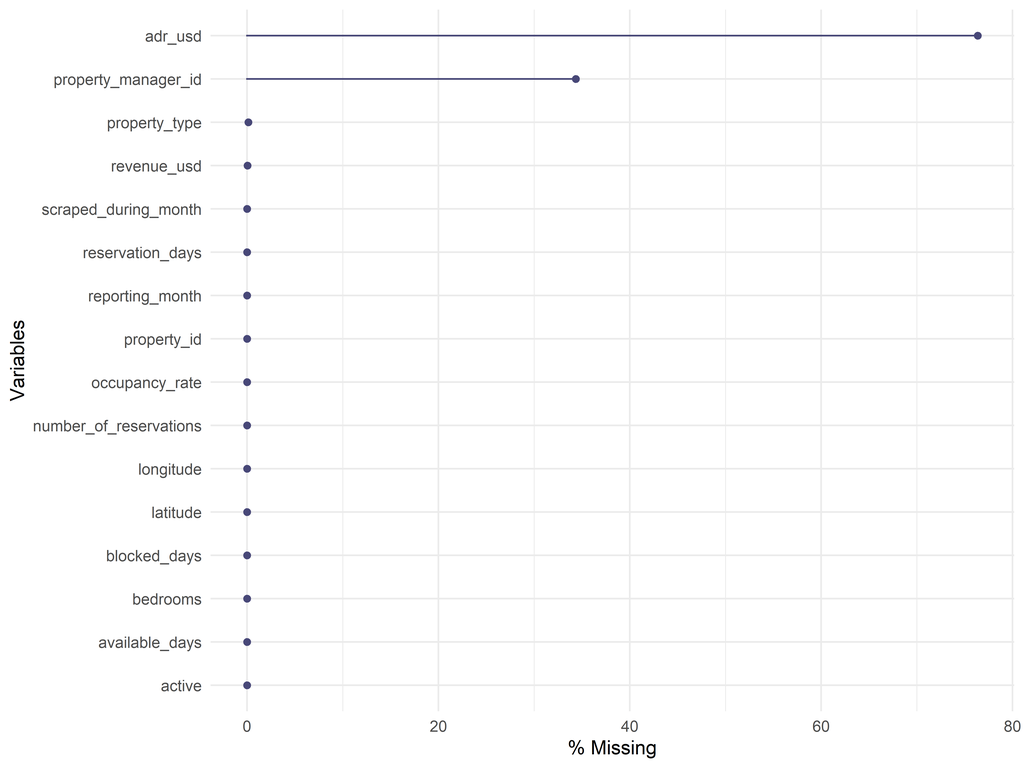

## 4.3 Reporting Month

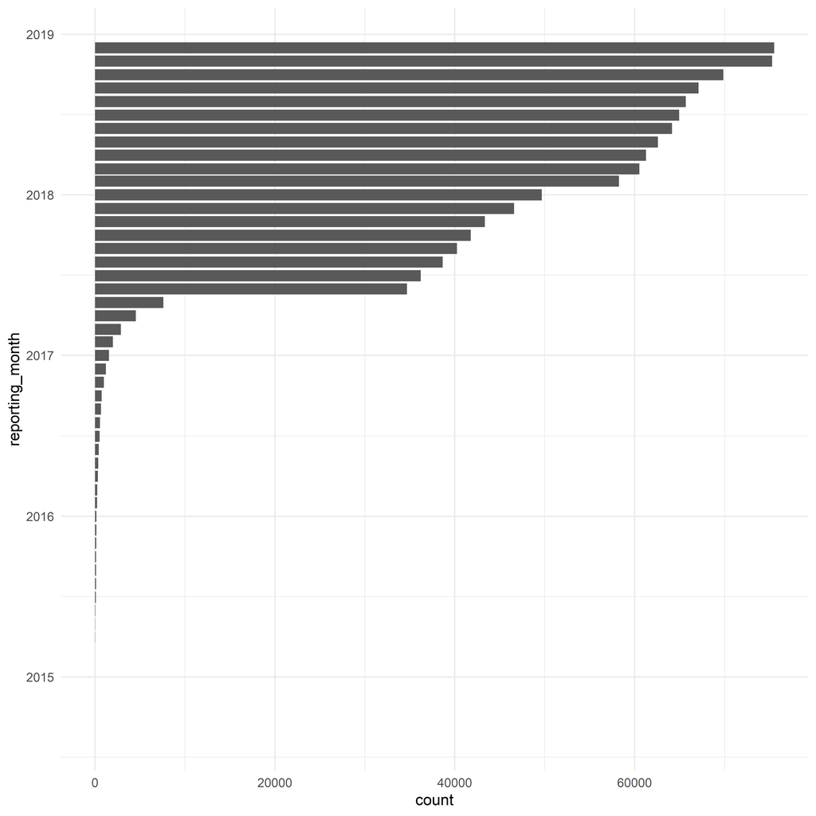

Clearly not all propoerties have all months!

Number of months proerty has data on:

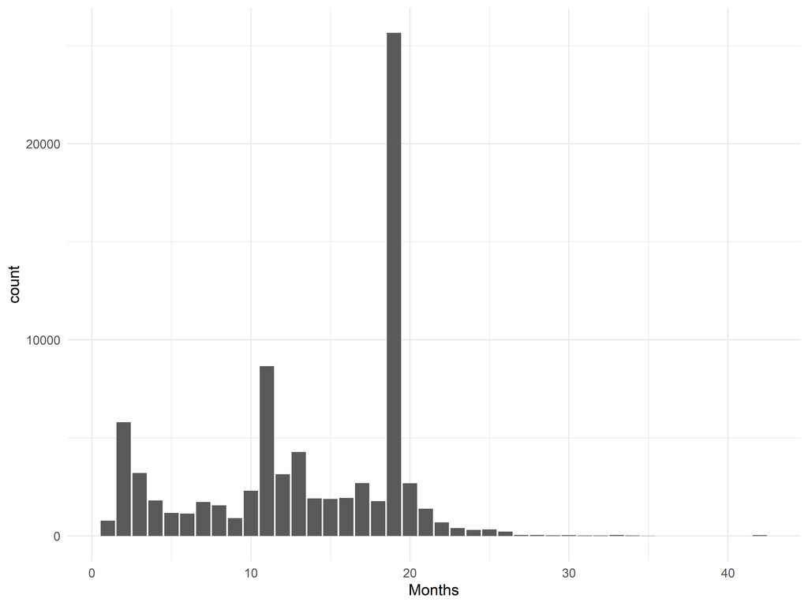

**Clear peaks at certain months?**

## 4.4 Active

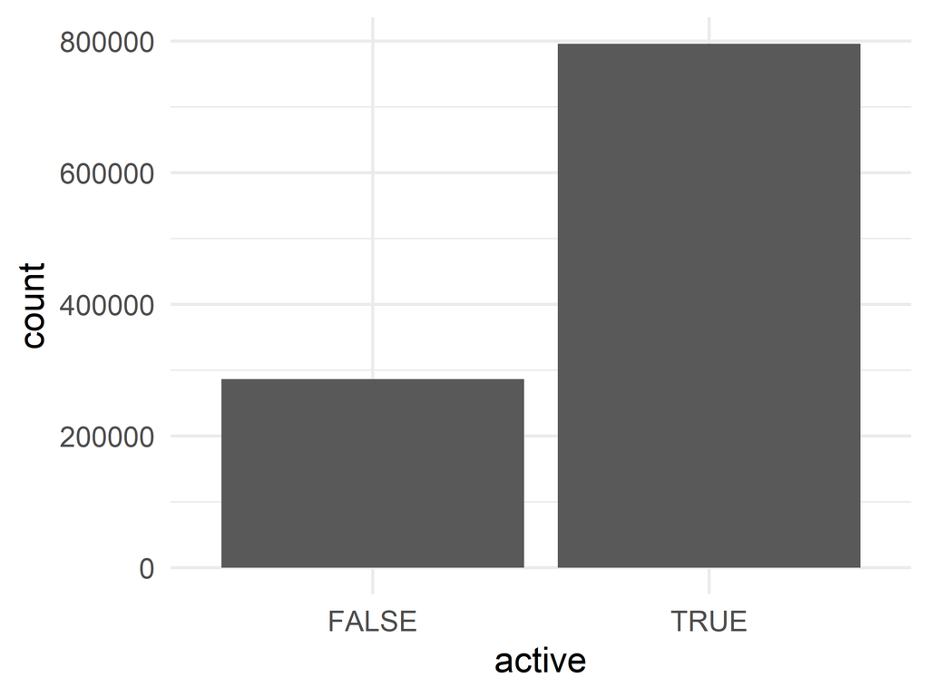

## 4.5 Occupancy Rate

```
## Descriptive Statistics
## ham$occupancy_rate
## N: 1082116
##
##                occupancy_rate
## ------------ ----------------
##         Mean             0.11
##       Median             0.00
##          Min             0.00
##          Max             1.00
```

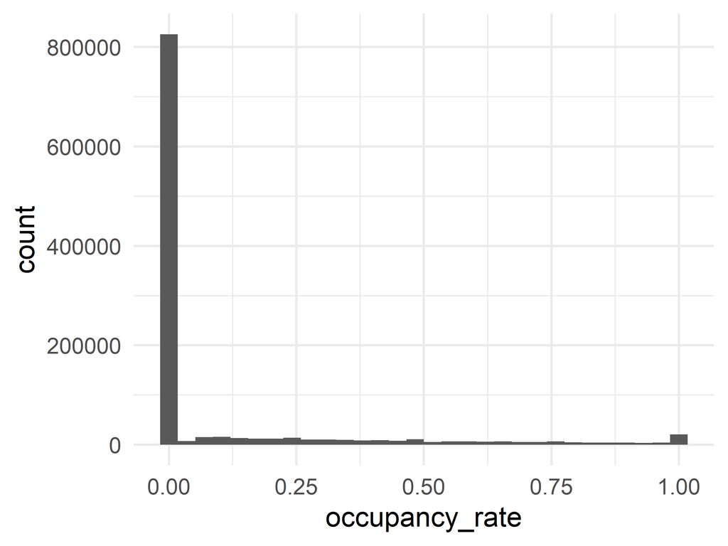

## 4.6 `revenue_usd`

```
## Descriptive Statistics
## ham$revenue_usd
## N: 1082116
##
##                 revenue_usd
## ------------ --------------
##         Mean         930.51
##       Median           0.00
##          Min           0.00
##          Max   270793000.00
```